# Classificação com NaiveBayes

```
Conteudo sobre NaiveBayes

Livro Thoughtful Machine Learning de Matthew Kirk: o capítulo 4 apresenta mais sobre a teoria do
Naive Bayes  e mostra como construir um classificador de spam

Livro Data Algorithms de Mahmoud Parsian: o capítulo 14 apresenta explicações sobre a teoria do Naive Bayes
```

### O que é NaiveBayes

link: https://www.vooo.pro/insights/6-passos-faceis-para-aprender-o-algoritmo-naive-bayes-com-o-codigo-em-python/

O que é o algoritmo Naive Bayes? É uma técnica de classificação baseado no teorema de Bayes com uma suposição de independência entre os preditores. Em termos simples, um classificador Naive Bayes assume que a presença de uma característica particular em uma classe não está relacionada com a presença de qualquer outro recurso. Por exemplo, um fruto pode ser considerado como uma maçã se é vermelho, redondo, e tiver cerca de 3 polegadas de diâmetro. Mesmo que esses recursos dependam uns dos outros ou da existência de outras características, todas estas propriedades contribuem de forma independente para a probabilidade de que este fruto é uma maçã e é por isso que é conhecido como ‘Naive’ (ingênuo).

O modelo Naive Bayes é fácil de construir e particularmente útil para grandes volumes de dados. Além de simples, Naive Bayes é conhecido por ganhar de métodos de classificação altamente sofisticados.

Teorema de Bayes fornece uma forma de calcular a probabilidade posterior P (C | X) a partir de P (C), P (x) e P (X | c). Veja a equação abaixo:

probabilidade Bayes

[figure not shown]

Acima,

P (c | x) é a probabilidade posterior da classe (c, alvo) dada preditor (x, atributos). P (c) é a probabilidade original da classe. P (x | c) é a probabilidade que representa a probabilidade de preditor dada a classe. P (x) é a probabilidade original do preditor. Como o algoritmo Naive Bayes funciona? Vamos entender isso usando um exemplo. Abaixo eu tenho um conjunto de dados de treinamento de clima e da correspondente variável-alvo ‘Play’ (sugerindo possibilidades de jogar). Agora, precisamos classificar se os jogadores vão jogar ou não com base na condição meteorológica. Vamos seguir os passos abaixo para realizar a operação.

Passo 1: Converter o conjunto de dados em uma tabela de frequência

Passo 2: Criar tabela de Probabilidade ao encontrar as probabilidades de tempo Nublado = 0,29 e probabilidade de jogar = 0,64.

tabela bayes Passo 3: Agora, use a equação Bayesiana Naive para calcular a probabilidade posterior para cada classe. A classe com maior probabilidade posterior é o resultado da previsão.

Problema: Os jogadores irão jogar se o tempo está ensolarado. Esta afirmação está correta?

Podemos resolver isso usando o método discutido acima de probabilidade posterior.

P (Sim |Ensolarado) = P (Ensolarado | Sim) * P (Sim) / P (Ensolarado)

Aqui temos P (Ensolarado | Sim) = 3/9 = 0,33, P (Ensolarado) = 5/14 = 0,36, P (Sim) = 9/14 = 0,64

[figure not shown]

Agora, P (Sim | Ensolarado) = 0,33 * 0,64 / 0,36 = 0,60, que tem maior probabilidade.

Naive Bayes usa um método similar para prever a probabilidade de classe diferente com base em vários atributos. Este algoritmo é usado principalmente em classificação de texto e com os problemas que têm múltiplas classes.

### Aplicações

Previsões em tempo real: Naive Bayes é um classificador de aprendizagem voraz e com certeza rápido. Assim, pode ser usado para fazer previsões em tempo real.

Previsões multi-classes: Este algoritmo também é conhecido pela funcionalidade de previsão multi-classes. Aqui podemos prever a probabilidade de múltiplas classes das variáveis-alvo.

Classificação de textos/Filtragem de spam/Análise de sentimento: classificadores Naive Bayes utilizados principalmente em classificação de textos (devido a um melhor resultado em problemas de classes múltiplas e regra de independência) têm maior taxa de sucesso em comparação com outros algoritmos. Como resultado, é amplamente utilizado na filtragem de spam (identificar spam) e Análise de Sentimento (em análise de mídia social, para identificar sentimentos positivos e negativos dos clientes)

Sistema de Recomendação: o classificador e a filtragem colaborativa Naive Bayes em conjunto constroem um sistema de recomendação que utiliza técnicas de machine learning e mineração de dados para filtrar a informação invisível e prever se um usuário gostaria de um determinado recurso ou não

### Prós-Contras

Quais são os prós e contras de Naive Bayes? Prós:

- É fácil e rápido para prever o conjunto de dados da classe de teste. Também tem um bom desempenho na previsão de classes múltiplas.
- Quando a suposição de independência prevalece, um classificador Naive Bayes tem melhor desempenho em comparação com outros modelos como regressão logística, e você precisa de menos dados de treinamento.
- O desempenho é bom em caso de variáveis categóricas de entrada comparada com a variáveis numéricas. Para variáveis numéricas, assume-se a distribuição normal (curva de sino, que é uma suposição forte).

Contras:

- Se a variável categórica tem uma categoria (no conjunto de dados de teste) que não foi observada no conjunto de dados de treinamento, então o modelo irá atribuir uma probabilidade de 0 (zero) e não será capaz de fazer uma previsão. Isso é muitas vezes conhecido como “Zero Frequency”. Para resolver isso, podemos usar a técnica de alisamento. Uma das técnicas mais simples de alisamento é a chamada estimativa de Laplace.
- Por outro lado naive Bayes é também conhecido como um mau estimador, por isso, as probabilidades calculadas não devem ser levadas muito a sério.
- Outra limitação do Naive Bayes é a suposição de preditores independentes. Na vida real, é quase impossível que ter um conjunto de indicadores que sejam completamente independentes.

DESVANTAGEM

- NaiveByes trata cada coluna como independente o que nem sempre é verdade

## Exemplo de NaiveBayes

Exemplo para uma tabela de dados de NaiveBayes

[figure not shown]

## Classificação do Exemplo: Análise de Risco

```python
import pandas as pd
import numpy as np
import matplotlib.pyplot as plt
```

### PreProcess - Divisão e codificação da base

```python
base = pd.read_csv('files/risco_credito.csv')
```

```python
base.head()
```

|  | historia | divida | garantias | renda | c#risco |
| --- | --- | --- | --- | --- | --- |
| 0 | ruim | alta | nenhuma | 0_15 | alto |
| 1 | desconhecida | alta | nenhuma | 15_35 | alto |
| 2 | desconhecida | baixa | nenhuma | 15_35 | moderado |
| 3 | desconhecida | baixa | nenhuma | acima_35 | alto |
| 4 | desconhecida | baixa | nenhuma | acima_35 | baixo |

```python
# Divisão da base em features e classe
previsores = base.iloc[:,0:4].values
classe = base.iloc[:,4].values
```

```python
# Antes da condificaçâo da variável categórica
previsores[0]
```

```
array(['ruim', 'alta', 'nenhuma', '0_15'], dtype=object)
```

```python
# NaiveBayes nâo aecita atributos categóricos
# Então temos que substitui por atributos discretos
from sklearn.preprocessing import LabelEncoder
labelencoder = LabelEncoder() # Vai codificar para cada clases : 0,1,2,3...
previsores[:,0] = labelencoder.fit_transform(previsores[:,0])
previsores[:,1] = labelencoder.fit_transform(previsores[:,1])
previsores[:,2] = labelencoder.fit_transform(previsores[:,2])
previsores[:,3] = labelencoder.fit_transform(previsores[:,3])
```

```python
previsores[0]
```

```
array([3, 0, 1, 0], dtype=object)
```

### Classificador `GaussianNB`

```python
from sklearn.naive_bayes import GaussianNB
classificador = GaussianNB()
classificador.fit(previsores, classe)
```

```
GaussianNB(priors=None, var_smoothing=1e-09)
```

### Classificando um registro

"boa, divida alta, garantia nenhuma, renda: >35"

```python
resultado = classificador.predict([[0,0,1,2], [3, 0, 0, 0]])
print(resultado)
# Dados do Classificador
print(classificador.classes_) # Quais são as classes?
print(classificador.class_count_) # Contagem do historico para cada cla
print(classificador.class_prior_) # probabilidades a priori: a prob s'baseadonas ocorrencias das tags
```

```
['baixo' 'moderado']
['alto' 'baixo' 'moderado']
[6. 5. 3.]
[0.42857143 0.35714286 0.21428571]
```

## credit_risc

### PreProcess e Divisão da Base

`mesmos passo da etapa 1.Pre-Process`

```python
base = pd.read_csv('files/credit_data.csv')
base.loc[base.age < 0, 'age'] = 40.92

previsores = base.iloc[:, 1:4].values
classe = base.iloc[:, 4].values

from sklearn.impute import SimpleImputer
imputer = SimpleImputer(
    missing_values=np.nan, strategy = 'mean')
imputer = imputer.fit(previsores[:, 1:4])
previsores[:, 1:4] = imputer.transform(
    previsores[:, 1:4])

from sklearn.preprocessing import StandardScaler
scaler = StandardScaler()
previsores = scaler.fit_transform(previsores)

from sklearn.model_selection import train_test_split
previsores_treinamento, previsores_teste, classe_treinamento, classe_teste = train_test_split(
    previsores, classe, test_size=0.25, random_state=0)
```

```python
previsores_treinamento
```

```
array([[-1.3754462 ,  0.50631087,  0.10980934],
       [ 1.45826409, -1.6489393 , -1.21501497],
       [-0.79356829,  0.22531191, -0.43370226],
       ...,
       [ 0.21738243, -0.14704404,  1.40872498],
       [ 0.58716195,  0.66435493,  0.67948086],
       [ 0.68315357,  0.04084946,  1.91819744]])
```

```python
classe_treinamento
```

```
array([0, 0, 0, ..., 0, 0, 0])
```

### Criando Classificador

```python
from sklearn.naive_bayes import GaussianNB
classificador = GaussianNB()

# Treinando NaiveBayes
classificador.fit(previsores_treinamento, classe_treinamento)

# Prevendo a Base de Teste com o NaiveBayes Treinado
previsoes = classificador.predict(previsores_teste)
```

### Avaliando Classificador com a Matriz de Confusão

```python
from sklearn.metrics import confusion_matrix, accuracy_score

precisao = accuracy_score(classe_teste, previsoes)
print("Percentual de acerto do algoritmo", precisao)

matriz = confusion_matrix(classe_teste, previsoes)
print("Matriz de Confusao: A diagonal principal é o acerto\n", matriz)
```

```
Percentual de acerto do algoritmo 0.938
Matriz de Confusao: A diagonal principal é o acerto
 [[428   8]
 [ 23  41]]
```

## Census

```python
base = pd.read_csv('files/census.csv')

previsores = base.iloc[:, 0:14].values
classe = base.iloc[:, 14].values

from sklearn.preprocessing import OneHotEncoder
from sklearn.compose import ColumnTransformer

onehotencorder = ColumnTransformer(transformers=[
    ("OneHot", OneHotEncoder(), [1,3,5,6,7,8,9,13])],remainder='passthrough')
previsores = onehotencorder.fit_transform(previsores).toarray()

labelencorder_classe = LabelEncoder()
classe = labelencorder_classe.fit_transform(classe)

### Se fizer o escalonamento (o que é o mais comun ocorre), vai prejudicar o desempenho.
### Pois vai escalonar as novas colunas geradas pelo dummies, asim, em vez de ser 0 ou 1
###     vai ter valores intermediários.
# from sklearn.preprocessing import StandardScaler
# scaler = StandardScaler()
# previsores = scaler.fit_transform(previsores)

from sklearn.model_selection import train_test_split
previsores_treinamento, previsores_teste, classe_treinamento, classe_teste = train_test_split(
    previsores, classe, test_size=0.15, random_state=0)
```

### Classificador NaiveBayes

```python
from sklearn.naive_bayes import GaussianNB
classificador = GaussianNB()
classificador.fit(previsores_treinamento, classe_treinamento)
previsoes = classificador.predict(previsores_teste)
```

### Avaliando o algoritmo

```python
from sklearn.metrics import confusion_matrix, accuracy_score
precisao = accuracy_score(classe_teste, previsoes)
matriz = confusion_matrix(classe_teste, previsoes)
```

```python
precisao
```

```
0.7950870010235415
```

```python
matriz
```

```
array([[3515,  178],
       [ 823,  369]])
```

### OBS

No exemplo do IA Expert ele faz o escalonamento após criar as variáveis Dummies. Dessa forma ele chegaa 49%. Isso porque as várias colunas criadas pelo `dummies` viram números entre [0,1] o que atrapalha o algoritmo

**CONCLUSÃO: SE UM ALGORTIMO ESTIVER DANDO RUIM, VOCÊ PODE ANALISAR O CONTEXTO PARA TENTAR MELHORÁ-LO. NESSE CASO A APLICAÇÂO DO ESCALONAMENTO SE MOSTROU PREJUDICIAL AO ALGORITMO**

### Questionário

- Sobre a Correção Laplaciana, é correto afirmar que essa técnica adiciona um registro na base quando existirem partes na tabela de probabilidade nas quais não existem vinculações com a classe (TRUE)
- Para realizar as estimativas de probabilidade, o algoritmo Naïve Bayes pode utilizar uma técnica chamada radius (raio) que consiste em estabelecer um raio no entorno do atributo a ser classificado (TRUE)

# Exemplo do English ML-AZ

Objetivo: Prediction system to predict which user is going to buy a product displayed on a social media advertisement.

```python
dataset = pd.read_csv('../../files/Social_Network_Ads.csv')
```

```python
dataset.head()
```

|  | User ID | Gender | Age | EstimatedSalary | Purchased |
| --- | --- | --- | --- | --- | --- |
| 0 | 15624510 | Male | 19 | 19000 | 0 |
| 1 | 15810944 | Male | 35 | 20000 | 0 |
| 2 | 15668575 | Female | 26 | 43000 | 0 |
| 3 | 15603246 | Female | 27 | 57000 | 0 |
| 4 | 15804002 | Male | 19 | 76000 | 0 |

```python
# Splitting the dataset into the Training set and Test set
X = dataset.iloc[:, [2, 3]].values
y = dataset.iloc[:, 4].values

from sklearn.model_selection import train_test_split
X_train, X_test, y_train, y_test = train_test_split(X, y, test_size = 0.25, random_state = 0)
```

```python
from sklearn.preprocessing import StandardScaler
sc = StandardScaler()
X_train = sc.fit_transform(X_train)
X_test = sc.transform(X_test)
```

```python
# Fitting Naive Bayes to the Training set
from sklearn.naive_bayes import GaussianNB
classifier = GaussianNB()
classifier.fit(X_train, y_train)
```

```
GaussianNB(priors=None, var_smoothing=1e-09)
```

```python
# Predicting the Test set results
y_pred = classifier.predict(X_test)

# Making the Confusion Matrix
from sklearn.metrics import confusion_matrix
cm = confusion_matrix(y_test, y_pred)
cm
```

```
array([[65,  3],
       [ 7, 25]])
```

[output not shown]

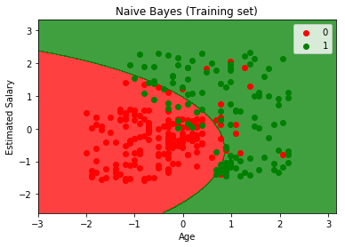

```python
# Visualising the Training set results
from matplotlib.colors import ListedColormap
X_set, y_set = X_train, y_train
X1, X2 = np.meshgrid(np.arange(start = X_set[:, 0].min() - 1, stop = X_set[:, 0].max() + 1, step = 0.01),
                     np.arange(start = X_set[:, 1].min() - 1, stop = X_set[:, 1].max() + 1, step = 0.01))
plt.contourf(X1, X2, classifier.predict(np.array([X1.ravel(), X2.ravel()]).T).reshape(X1.shape),
             alpha = 0.75, cmap = ListedColormap(('red', 'green')))
plt.xlim(X1.min(), X1.max())
plt.ylim(X2.min(), X2.max())
for i, j in enumerate(np.unique(y_set)):
    plt.scatter(X_set[y_set == j, 0], X_set[y_set == j, 1],
                c = ListedColormap(('red', 'green'))(i), label = j)
plt.title('Naive Bayes (Training set)')
plt.xlabel('Age')
plt.ylabel('Estimated Salary')
plt.legend()
plt.show()
```

[output not shown]

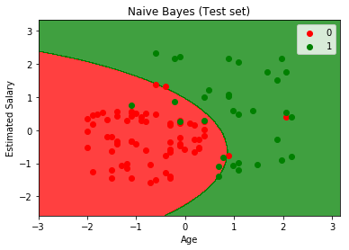

```python
# Visualising the Test set results
from matplotlib.colors import ListedColormap
X_set, y_set = X_test, y_test
X1, X2 = np.meshgrid(np.arange(start = X_set[:, 0].min() - 1, stop = X_set[:, 0].max() + 1, step = 0.01),
                     np.arange(start = X_set[:, 1].min() - 1, stop = X_set[:, 1].max() + 1, step = 0.01))
plt.contourf(X1, X2, classifier.predict(np.array([X1.ravel(), X2.ravel()]).T).reshape(X1.shape),
             alpha = 0.75, cmap = ListedColormap(('red', 'green')))
plt.xlim(X1.min(), X1.max())
plt.ylim(X2.min(), X2.max())
for i, j in enumerate(np.unique(y_set)):
    plt.scatter(X_set[y_set == j, 0], X_set[y_set == j, 1],
                c = ListedColormap(('red', 'green'))(i), label = j)
plt.title('Naive Bayes (Test set)')
plt.xlabel('Age')
plt.ylabel('Estimated Salary')
plt.legend()
plt.show()
```

# Perguntas do PDF ENlgish ML-AZ

Is Naive Bayes a linear model or a non linear model?

Naive Bayes is a non linear model. You will see that very clearly in Python or R when plotting the prediction boundary which will be a very nice curve well separating the non linearly distributed observations.

Can P (x) be zero?

Yes P (X) can be zero. That can happen when the new data point is an outlier, and therefore there is no other data points within the radius of the circle. However the formula in the Naive Bayes theorem is only true when P (X) is different than zero. When P (X) is equal to zero, then P (W alks|X) is just set to zero.

How does the algorithm decide the circle?

In the Intuition lecture we see that a circle is drawn to create a collection of data points similar to the new datapoint. The new datapoint was roughly at the center of the circle and hence we saw that number of green points were lesser than the number of red points and hence the new point went to the red category. But if we had drawn the circle a little differently around the new datapoint, then the number of green points could have been more than red. So how is that circle chosen? There is a parameter in the model that decides the radius of the circle, just like there is a parameter that chooses the number of neighbors in K-NN.

Naive Bayes vs K-NN?

The best way to answer that question is to try them both. Thanks to the templates it will only take a few minutes to compare their results. Just understand that the main difference between the two is that Naive Bayes is based on a probabilistic approach, unlike classic K-NN.

NaivieBayes in Python

What does the fit method do here?

It will simply train the Naive Bayes model on X_train and y_train. More precisely, the fit method will collect the data in X_train and y_train, and from that it will do all the successive operations you saw in the Intuition Lecture: first it will get the prior probability, the marginal likelihood, the likelihood and the posterior probability, and then using the circles around the observations it will learn how to classify these observations and predict future outcomes.

How to get the probabilities as output?

Here is the way to do that: `y_proba = classifier.predict_proba(X_test)` This will give you an array with 2 columns, one for 0 and one for 1.